# 통계학실험(009)과제10

박현 2019-14593

2019년 6월 5일

### 예제1.

어느 시장 조사기관은 여러 가지 대중매체가 주는 정보의 양을 비교하기 위해 다음과 같은 실험을 계획하였다. 40명의 성인을 랜덤하게 추출하여 철저한 면접을 통해 TV, 신문, 라디오, 잡지 중 어느 매체를 많이 접하는지에 따라 분류하였다. 다음 표는 최근에 일어난 사건들에 대한 조사 대상자들의 인지도를 측정한 실험에서 얻어진 값들을 나타내고, 값이 클수록 인지도가 높은 것을 의미한다. 이 자료를 이용하여 사람들의 인지도가 대중매체에 따라 다르다고 할 수 있는지 유의수준 5%에서 검정해보자.

귀무가설: 사람들의 인지도가 대중매체에 따라 차이가 없다.

대립가설: not 귀무가서

분산분석 결과, 검정통계량의 값은 8.2677이고 유의확률은 0.0002587로 0.05보다 작은 것으로 나타 났다. 따라서 유의수준 5%에서 모평균이 모두 동일하다는 귀무가설을 기각할 수 있다. 즉, 사람들의 인지도가 대중매체에 따라 차이가 있다는 결론을 얻을 수 있다.

```r
media = factor(rep(c("TV","신문","라디오","잡지"),c(10,11,9,10)))
awareness = c(16,19,25,22,21,15,16,22,21,18,13,14,15,16,15,13,19,16,20,14,11,18,18,15,14,14,10,18,15,15,11,15,11,17,17,13,14,16,13,11)
data = data.frame(awareness, media)
fit = lm(awareness ~ media, data=data)
anova(fit)
```

```
## Analysis of Variance Table
##
## Response: awareness
##           Df Sum Sq Mean Sq F value    Pr(>F)
## media      3 185.03  61.678  8.2677 0.0002587 ***
## Residuals 36 268.56   7.460
## ---
## Signif. codes:  0 '***' 0.001 '**' 0.01 '*' 0.05 '.' 0.1 ' ' 1
```

### 예제2.

어느 회사의 마케팅 부서에서는 하나의 상품에 대해 세 가지 다른 디자인의 포장을 적용한 후 이 상품들을 서로 다른 5군데의 상점에서 한 달 동안 판매하였다. 그리고 그 판매 결과는 아래와 같다. 제품의 매출은 판매되는 상점과 제품의 포장 디자인에 따라 다르다고 할 수 있는가? 적절한 가설을 쓰고 유의수준 5%에서 이를 검정하시오.

귀무가설: 상점과 상자에 따른 제품 매출의 효과는 없다

대립가설: not 귀무가설

분산분석표 확인 결과, 상점(store)의 효과에 대한 유의 확률은 0.6114로 유의수준 0.05보다 높고 상자(box)의 효과에 대한 유의 확률은 3.396e-05로 유의수준 0.05보다 낮다. 따라서 제품의 매출은 상점에 영향이 없으나 상자에 따라서 유의한 차이가 있다.

```r
store = factor(rep(1:5, 3))
box = factor(rep(1:3, rep(5,3)))
y = c(210,230,190,180,190,195,170,200,190,193,295,275,290,275,265)
cor = data.frame(store, box, y)

fit2 = lm(y ~ store+ box, data=cor)
anova(fit2)
```

```
## Analysis of Variance Table
##
## Response: y
##           Df  Sum Sq Mean Sq F value    Pr(>F)
## store      4   711.1   177.8  0.7033    0.6114
## box        2 24467.2 12233.6 48.3988 3.396e-05 ***
## Residuals  8  2022.1   252.8
## ---
## Signif. codes:  0 '***' 0.001 '**' 0.01 '*' 0.05 '.' 0.1 ' ' 1
```

### 예제3.

남녀의 성별과 고단백질로 구성된 아침 식사의 섭취 여부가 성인의 신체적 활동 능력에 영향을 미치는지를 알아보기 위하여 랜덤하게 선택된 남녀 10명에 대해 각각 5명씩 고단백질 아침식사와 저단백질 아침식사를 섭취하게 한 후, 신체적 능력을 테스트를 통해 측정하였다. 측정된 점수가 높을수록 신체 활동 능력이 더 우수하다는 것을 의미한다. 실험 결과가 아래와 같을 때, 주어진 자료에 대해 이원배치법을 적용한 후 그 결과를 해석하여라.

귀무가설: 성인의 신체적 활동 능력의 성별(sex)와 고단백질로 구성된 아침 식사의 섭취 여부(food)에 따른 상호작용은 존재하지 않는다.

대립가설: not 귀무가설

귀무가설: 성별(sex)와 고단백질로 구성된 아침 식사의 섭취 여부(food)에 따른 성인의 신체적 활동 능력은 차이가 없다.

대립가설: not 귀무가설

평균 그림 확인 결과, 두 요인 사이에는 상호작용이 존재하지 않는 것으로 보인다. 분산분석 결과, 유의수준 5%에서 성인의 신체적 활동 능력의 성별(sex)와 고단백질로 구성된 아침 식사의 섭취 여부(food)에 따른 상호작용은 존재하지 않는 것으로 나타났다 (F=2.2222, p-value=0.1554875>0.05). 이는 앞서 평균 그림을 통해서도 확인할 수 있었다. 또한 고단백질로 구성된 아침 식사의 섭취 여부에 따라서 성인의 신체적 활동 능력은 차이가 존재하고 (p-value=0.0088144) 성인의 신체적 활동 능력은 차이가 존재한다(p-value=0.0003851).

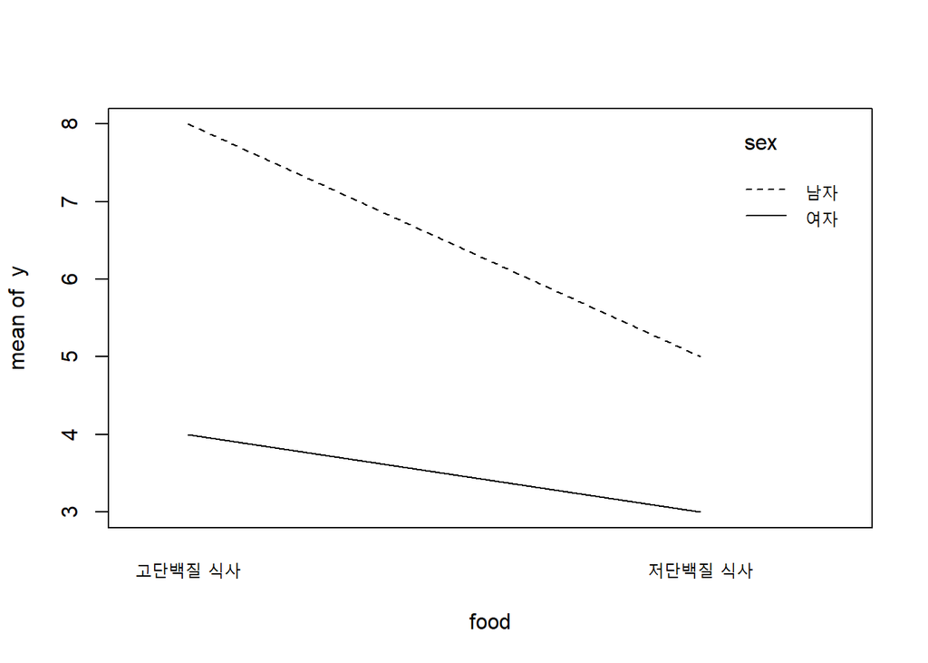

```r
food = factor(rep(cbind(rep("고단백질 식사",5),rep("저단백질 식사",5)),2))
sex = factor(cbind(rep("남자",10), rep("여자",10)))
y = c(10,7,9,6,8,5,4,7,4,5,5,4,6,3,2,3,4,5,1,2)

interaction.plot(food, sex, y)
```

```r
fit3 = lm(y ~ food * sex)
anova(fit3)
```

```
## Analysis of Variance Table
##
## Response: y
##           Df Sum Sq Mean Sq F value    Pr(>F)
## food       1     20   20.00  8.8889 0.0088144 **
## sex        1     45   45.00 20.0000 0.0003851 ***
## food:sex   1      5    5.00  2.2222 0.1554875
## Residuals 16     36    2.25
## ---
## Signif. codes:  0 '***' 0.001 '**' 0.01 '*' 0.05 '.' 0.1 ' ' 1
```